# Semi-Confirmatory Factor Analysis

Po-Hsien Huang

In this example, we will show how to use `lslx` to conduct semi-confirmatory factor analysis. The example uses data `HolzingerSwineford1939` in the package `lavaan`. Hence, `lavaan` must be installed.

## Model Specification

In the following specification, `x1` - `x9` is assumed to be measurements of 3 latent factors: `visual`, `textual`, and `speed`.

```r
model_fa <- "visual  :=> x1 + x2 + x3
             textual :=> x4 + x5 + x6
             speed   :=> x7 + x8 + x9
             visual  :~> x4 + x5 + x6 + x7 + x8 + x9
             textual :~> x1 + x2 + x3 + x7 + x8 + x9
             speed   :~> x1 + x2 + x3 + x4 + x5 + x6
             visual  <=> fix(1)* visual
             textual <=> fix(1)* textual
             speed   <=> fix(1)* speed"
```

## Object Initialization

`lslx` is written as an `R6` class. Every time we conduct analysis with `lslx`, an `lslx` object must be initialized. The following code initializes an `lslx` object named `lslx_fa`.

```r
library(lslx)
lslx_fa <- lslx$new(model = model_fa, data = lavaan::HolzingerSwineford1939)
```

```
An 'lslx' R6 class is initialized via 'data' argument.
  Response Variables: x1 x2 x3 x4 x5 x6 x7 x8 x9
  Latent Factors: visual textual speed
```

To see the model specification, we may use the `$extract_specification()` method.

```r
lslx_fa$extract_specification()
```

```
                             relation    left   right group reference matrix block  type start
x1<-1/g                         x1<-1      x1       1     g     FALSE  alpha  y<-1  free    NA
x2<-1/g                         x2<-1      x2       1     g     FALSE  alpha  y<-1  free    NA
x3<-1/g                         x3<-1      x3       1     g     FALSE  alpha  y<-1  free    NA
x4<-1/g                         x4<-1      x4       1     g     FALSE  alpha  y<-1  free    NA
x5<-1/g                         x5<-1      x5       1     g     FALSE  alpha  y<-1  free    NA
x6<-1/g                         x6<-1      x6       1     g     FALSE  alpha  y<-1  free    NA
x7<-1/g                         x7<-1      x7       1     g     FALSE  alpha  y<-1  free    NA
x8<-1/g                         x8<-1      x8       1     g     FALSE  alpha  y<-1  free    NA
x9<-1/g                         x9<-1      x9       1     g     FALSE  alpha  y<-1  free    NA
x1<-visual/g               x1<-visual      x1  visual     g     FALSE   beta  y<-f  free    NA
x2<-visual/g               x2<-visual      x2  visual     g     FALSE   beta  y<-f  free    NA
x3<-visual/g               x3<-visual      x3  visual     g     FALSE   beta  y<-f  free    NA
x4<-visual/g               x4<-visual      x4  visual     g     FALSE   beta  y<-f   pen    NA
x5<-visual/g               x5<-visual      x5  visual     g     FALSE   beta  y<-f   pen    NA
x6<-visual/g               x6<-visual      x6  visual     g     FALSE   beta  y<-f   pen    NA
x7<-visual/g               x7<-visual      x7  visual     g     FALSE   beta  y<-f   pen    NA
x8<-visual/g               x8<-visual      x8  visual     g     FALSE   beta  y<-f   pen    NA
x9<-visual/g               x9<-visual      x9  visual     g     FALSE   beta  y<-f   pen    NA
x1<-textual/g             x1<-textual      x1 textual     g     FALSE   beta  y<-f   pen    NA
x2<-textual/g             x2<-textual      x2 textual     g     FALSE   beta  y<-f   pen    NA
x3<-textual/g             x3<-textual      x3 textual     g     FALSE   beta  y<-f   pen    NA
x4<-textual/g             x4<-textual      x4 textual     g     FALSE   beta  y<-f  free    NA
x5<-textual/g             x5<-textual      x5 textual     g     FALSE   beta  y<-f  free    NA
x6<-textual/g             x6<-textual      x6 textual     g     FALSE   beta  y<-f  free    NA
x7<-textual/g             x7<-textual      x7 textual     g     FALSE   beta  y<-f   pen    NA
x8<-textual/g             x8<-textual      x8 textual     g     FALSE   beta  y<-f   pen    NA
x9<-textual/g             x9<-textual      x9 textual     g     FALSE   beta  y<-f   pen    NA
x1<-speed/g                 x1<-speed      x1   speed     g     FALSE   beta  y<-f   pen    NA
x2<-speed/g                 x2<-speed      x2   speed     g     FALSE   beta  y<-f   pen    NA
x3<-speed/g                 x3<-speed      x3   speed     g     FALSE   beta  y<-f   pen    NA
x4<-speed/g                 x4<-speed      x4   speed     g     FALSE   beta  y<-f   pen    NA
x5<-speed/g                 x5<-speed      x5   speed     g     FALSE   beta  y<-f   pen    NA
x6<-speed/g                 x6<-speed      x6   speed     g     FALSE   beta  y<-f   pen    NA
x7<-speed/g                 x7<-speed      x7   speed     g     FALSE   beta  y<-f  free    NA
x8<-speed/g                 x8<-speed      x8   speed     g     FALSE   beta  y<-f  free    NA
x9<-speed/g                 x9<-speed      x9   speed     g     FALSE   beta  y<-f  free    NA
visual<->visual/g     visual<->visual  visual  visual     g     FALSE    phi f<->f fixed     1
textual<->visual/g   textual<->visual textual  visual     g     FALSE    phi f<->f  free    NA
speed<->visual/g       speed<->visual   speed  visual     g     FALSE    phi f<->f  free    NA
```

[output cut: 49 more lines]

```
visual<->visual/g    <NA>    none   0      0
textual<->visual/g   <NA>    none   0      0
speed<->visual/g     <NA>    none   0      0
textual<->textual/g  <NA>    none   0      0
speed<->textual/g    <NA>    none   0      0
speed<->speed/g      <NA>    none   0      0
x1<->x1/g            <NA>    none   0      0
x2<->x2/g            <NA>    none   0      0
x3<->x3/g            <NA>    none   0      0
x4<->x4/g            <NA>    none   0      0
x5<->x5/g            <NA>    none   0      0
x6<->x6/g            <NA>    none   0      0
x7<->x7/g            <NA>    none   0      0
x8<->x8/g            <NA>    none   0      0
x9<->x9/g            <NA>    none   0      0
```

The row names show the coefficient names. The most two relevant columns are `type` which shows the type of the coefficient and `start` which gives the starting value. In `lslx`, many `extract` related methods are defined. `extract` related methods can be used to extract quantities stored in `lslx` object. For details, please see the section of Extract-Related Methods via `?lslx`.

## Model Fitting

After an `lslx` object is initialized, method `$fit()` can be used to fit the specified model to the given data.

```r
lslx_fa$fit(penalty_method = "mcp",
            lambda_grid = seq(.01, .60, .01),
            delta_grid = c(1.5, 3.0, Inf))
```

```
CONGRATS: Algorithm converges under EVERY specified penalty level.
  Specified Tolerance for Convergence: 0.001
  Specified Maximal Number of Iterations: 100
```

The fitting process requires users to specify the penalty method (argument `penalty_method`) and the considered penalty levels (argument `lambda_grid` and `delta_grid`). In this example, the `mcp` penalty is implemented on the lambda grid `seq(.01, .60, .01)` and delta grid `c(1.5, 3, Inf)`. Note that in this example `lambda = 0` is not considered because it may result in unidentified model. All the fitting result will be stored in the `fitting` field of `lslx_fa`.

## Model Summarizing

Unlike traditional SEM analysis, `lslx` fits the model into data under all the penalty levels considered. To summarize the fitting result, a selector to determine an optimal penalty level must be specified. Available selectors can be found in the section of Penalty Level Selection via `?lslx`. The following code summarize the fitting result under the penalty level selected by Bayesian information criterion (BIC).

```r
lslx_fa$summarize(selector = "bic")
```

```
General Information
   number of observations                                301
   number of complete observations                       301
   number of missing patterns                           none
   number of groups                                        1
   number of responses                                     9
   number of factors                                       3
   number of free coefficients                            30
   number of penalized coefficients                       18

Numerical Conditions
   selected lambda                                     0.140
   selected delta                                      1.500
   selected step                                        none
   objective value                                     0.158
   objective gradient absolute maximum                 0.001
   objective Hessian convexity                         0.593
   number of iterations                                8.000
   loss value                                          0.103
   number of non-zero coefficients                    34.000
   degrees of freedom                                 20.000
   robust degrees of freedom                          20.638
   scaling factor                                      1.032

Fit Indices
   root mean square error of approximation (rmsea)     0.043
   comparative fit index (cfi)                         0.988
   non-normed fit index (nnfi)                         0.978
   standardized root mean of residual (srmr)           0.030

Likelihood Ratio Test
                    statistic         df    p-value
   unadjusted          30.901     20.000      0.057
   mean-adjusted       29.946     20.000      0.071

Root Mean Square Error of Approximation Test
                     estimate      lower      upper
   unadjusted           0.043      0.000      0.075
   mean-adjusted        0.041      0.000      0.075

```

[output cut: 48 more lines]

```
          x7<->x7     free     0.596      0.109    5.462    0.000  0.382  0.810
          x8<->x8     free     0.488      0.084    5.772    0.000  0.322  0.653
          x9<->x9     free     0.540      0.064    8.430    0.000  0.415  0.666

  Intercept
                      type  estimate  std.error  z-value  P(>|z|)  lower  upper
            x1<-1     free     4.936      0.067   73.473    0.000  4.804  5.067
            x2<-1     free     6.088      0.068   89.855    0.000  5.955  6.221
            x3<-1     free     2.250      0.065   34.579    0.000  2.123  2.378
            x4<-1     free     3.061      0.067   45.694    0.000  2.930  3.192
            x5<-1     free     4.341      0.074   58.452    0.000  4.195  4.486
            x6<-1     free     2.186      0.063   34.667    0.000  2.062  2.309
            x7<-1     free     4.186      0.063   66.766    0.000  4.063  4.309
            x8<-1     free     5.527      0.058   94.854    0.000  5.413  5.641
            x9<-1     free     5.374      0.058   92.546    0.000  5.260  5.488
```

## Visualization

`lslx` provides four methods for visualizing the fitting results. The method `$plot_numerical_condition()` shows the numerical condition under all the penalty levels. The following code plots the values of `n_iter_out` (number of iterations in outer loop), `objective_gradient_abs_max` (maximum of absolute value of gradient of objective function), and `objective_hessian_convexity` (minimum of univariate approximate hessian). The plot can be used to evaluate the quality of numerical optimization.

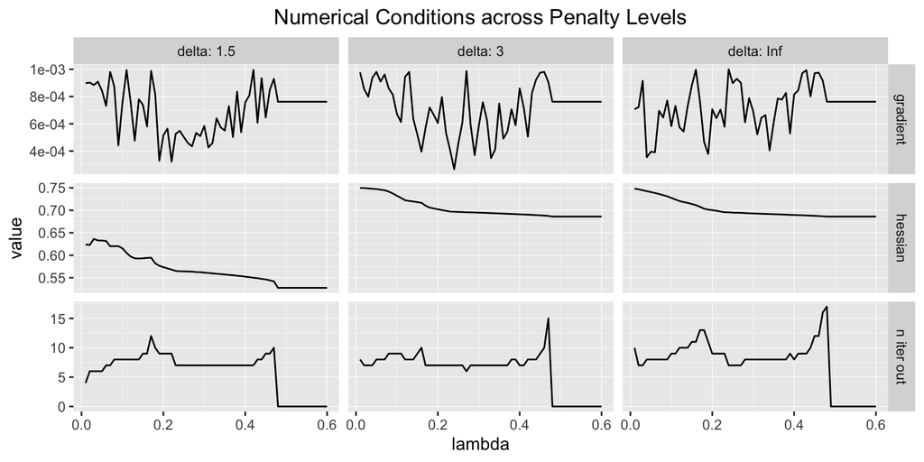

```r
lslx_fa$plot_numerical_condition()
```

The method `$plot_information_criterion()` shows the values of information criteria under all the penalty levels.

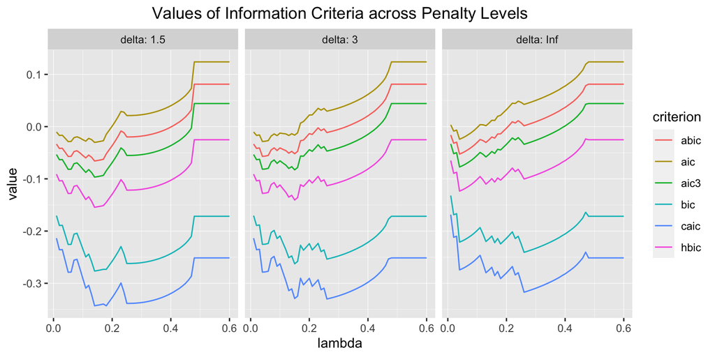

```r
lslx_fa$plot_information_criterion()
```

The method `$plot_fit_index()` shows the values of fit indices under all the penalty levels.

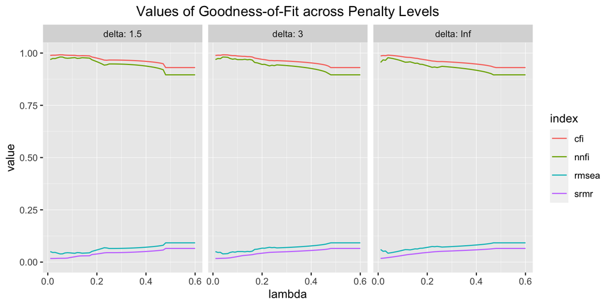

```r
lslx_fa$plot_fit_index()
```

The method `$plot_coefficient()` shows the solution path of coefficients in the given block. The following code plots the solution paths of all coefficients in the block `y<-f`, which contains all the regression coefficients from latent factors to observed variables (i.e., factor loadings).

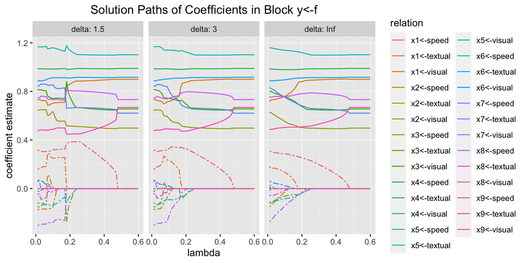

```r
lslx_fa$plot_coefficient(block = "y<-f")
```

## Objects Extraction

In `lslx`, many quantities related to SEM can be extracted by extract-related method. For example, the loading matrix can be obtained by

```r
lslx_fa$extract_coefficient_matrix(selector = "bic", block = "y<-f")
```

```
$g
   visual textual speed
x1  0.709   0.255 0.000
x2  0.555   0.000 0.000
x3  0.744   0.000 0.000
x4  0.000   0.987 0.000
x5 -0.103   1.143 0.000
x6  0.000   0.913 0.000
x7 -0.254   0.000 0.824
x8  0.000   0.000 0.731
x9  0.323   0.000 0.499
```

The model-implied covariance matrix and residual matrix can be obtained by

```r
lslx_fa$extract_implied_cov(selector = "bic")
```

```
$g
       x1     x2     x3    x4    x5    x6     x7    x8    x9
x1 1.3560 0.4393 0.5892 0.479 0.474 0.444 0.0754 0.245 0.423
x2 0.4393 1.3806 0.4129 0.178 0.149 0.165 0.0298 0.152 0.283
x3 0.5892 0.4129 1.2728 0.239 0.200 0.221 0.0399 0.203 0.379
x4 0.4793 0.1779 0.2386 1.350 1.095 0.901 0.1443 0.200 0.240
x5 0.4741 0.1493 0.2002 1.095 1.657 1.013 0.1618 0.204 0.226
x6 0.4436 0.1647 0.2208 0.901 1.013 1.196 0.1336 0.185 0.223
x7 0.0754 0.0298 0.0399 0.144 0.162 0.134 1.1832 0.533 0.381
x8 0.2455 0.1515 0.2033 0.200 0.204 0.185 0.5328 1.022 0.453
x9 0.4235 0.2828 0.3792 0.240 0.226 0.223 0.3812 0.453 1.014
```

```r
lslx_fa$extract_residual_cov(selector = "bic")
```

```
$g
         x1       x2       x3        x4       x5        x6        x7        x8       x9
x1 -0.00234  0.03193  0.00930 -0.025585  0.03353 -0.011256 -0.009370 -0.018374 -0.03488
x2  0.03193 -0.00115 -0.03820 -0.031019 -0.06184 -0.082892  0.126516  0.041886  0.03875
x3  0.00930 -0.03820 -0.00206  0.030436  0.08788 -0.023276 -0.048421 -0.009070  0.00538
x4 -0.02558 -0.03102  0.03044 -0.000296 -0.00288  0.005221 -0.075402  0.074744 -0.00295
x5  0.03353 -0.06184  0.08788 -0.002877 -0.00322 -0.001204  0.018757  0.023529 -0.06892
x6 -0.01126 -0.08289 -0.02328  0.005221 -0.00120 -0.000274 -0.010490  0.019983 -0.01349
x7 -0.00937  0.12652 -0.04842 -0.075402  0.01876 -0.010490  0.000101 -0.002465  0.00786
x8 -0.01837  0.04189 -0.00907  0.074744  0.02353  0.019983 -0.002465 -0.000357 -0.00433
x9 -0.03488  0.03875  0.00538 -0.002951 -0.06892 -0.013493  0.007861 -0.004325 -0.00093
```

## Wrapper Function `plsem()` and `S3` Methods

After version 0.6.3, the previous analysis can be equivalently conducted by `plsem()` with `lavaan` style model syntax.

```r
model_fa <- "visual  =~ x1 + x2 + x3
             textual =~ x4 + x5 + x6
             speed   =~ x7 + x8 + x9
             pen() * visual  =~ x4 + x5 + x6 + x7 + x8 + x9
             pen() * textual =~ x1 + x2 + x3 + x7 + x8 + x9
             pen() * speed   =~ x1 + x2 + x3 + x4 + x5 + x6
             visual  ~~ 1 * visual
             textual ~~ 1 * textual
             speed   ~~ 1 * speed"

lslx_fa <- plsem(model = model_fa,
                 data = lavaan::HolzingerSwineford1939,
                 penalty_method = "mcp",
                 lambda_grid = seq(.01, .60, .01),
                 delta_grid = c(1.5, 3.0, Inf))
```

```
An 'lslx' R6 class is initialized via 'data' argument.
  Response Variables: x1 x2 x3 x4 x5 x6 x7 x8 x9
  Latent Factors: visual textual speed
CONGRATS: Algorithm converges under EVERY specified penalty level.
  Specified Tolerance for Convergence: 0.001
  Specified Maximal Number of Iterations: 100
```

```r
summary(lslx_fa, selector = "bic")
```

```
General Information
   number of observations                                301
   number of complete observations                       301
   number of missing patterns                           none
   number of groups                                        1
   number of responses                                     9
   number of factors                                       3
   number of free coefficients                            30
   number of penalized coefficients                       18

Numerical Conditions
   selected lambda                                     0.140
   selected delta                                      1.500
   selected step                                        none
   objective value                                     0.158
   objective gradient absolute maximum                 0.001
   objective Hessian convexity                         0.593
   number of iterations                                8.000
   loss value                                          0.103
   number of non-zero coefficients                    34.000
   degrees of freedom                                 20.000
   robust degrees of freedom                          20.641
   scaling factor                                      1.032

Fit Indices
   root mean square error of approximation (rmsea)     0.043
   comparative fit index (cfi)                         0.988
   non-normed fit index (nnfi)                         0.978
   standardized root mean of residual (srmr)           0.030

Likelihood Ratio Test
                    statistic         df    p-value
   unadjusted          30.902     20.000      0.056
   mean-adjusted       29.942     20.000      0.071

Root Mean Square Error of Approximation Test
                     estimate      lower      upper
   unadjusted           0.043      0.000      0.075
   mean-adjusted        0.041      0.000      0.075

```

[output cut: 48 more lines]

```
          x7<->x7     free     0.596      0.109    5.467    0.000  0.383  0.810
          x8<->x8     free     0.487      0.084    5.767    0.000  0.322  0.653
          x9<->x9     free     0.540      0.064    8.431    0.000  0.414  0.666

  Intercept
                      type  estimate  std.error  z-value  P(>|z|)  lower  upper
            x1<-1     free     4.936      0.067   73.473    0.000  4.804  5.067
            x2<-1     free     6.088      0.068   89.855    0.000  5.955  6.221
            x3<-1     free     2.250      0.065   34.579    0.000  2.123  2.378
            x4<-1     free     3.061      0.067   45.694    0.000  2.930  3.192
            x5<-1     free     4.341      0.074   58.452    0.000  4.195  4.486
            x6<-1     free     2.186      0.063   34.667    0.000  2.062  2.309
            x7<-1     free     4.186      0.063   66.766    0.000  4.063  4.309
            x8<-1     free     5.527      0.058   94.854    0.000  5.413  5.641
            x9<-1     free     5.374      0.058   92.546    0.000  5.260  5.488
```